# Part II - Analysis of San Francisco Bay Ford GoBike System

## by Matthew Olushola Odebunmi

## Investigation Overview

> **I am interested in the duration of the trips** we can see the most prominnent Start Staion Name and End Station name

> 90.53% that undergo the trips were Subscriber while only 9.47% were Customer

> The distribution of the start time chart show 2 peak of 8 hour and 17 hour

## Dataset Overview

### The Dataset contains 16 Features

> 1. Time duration in seconds
> 2. Start time and date
> 3. End time and date
> 4. Start Station ID
> 5. Start Station Name
> 6. Start Station Latitude
> 7. Start Station Longitude
> 8. End Station ID
> 9. End Station Name
> 10. End Station Latitude
> 11. End station Longitude
> 12. Bike ID
> 13. User Type
> 14. Member Birth year
> 15. Member Gender
> 16. Bike Share for all Trip The dataset has 174952 entries

## Start Station Name For The Trip

> The Most Popular 15 Start Station Name

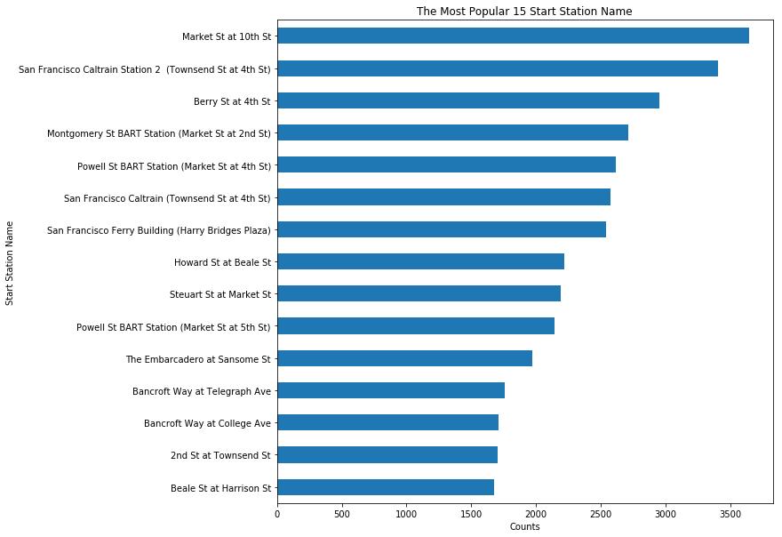

## End Station Name For The Trip

> The Most Popular 15 End Station Name

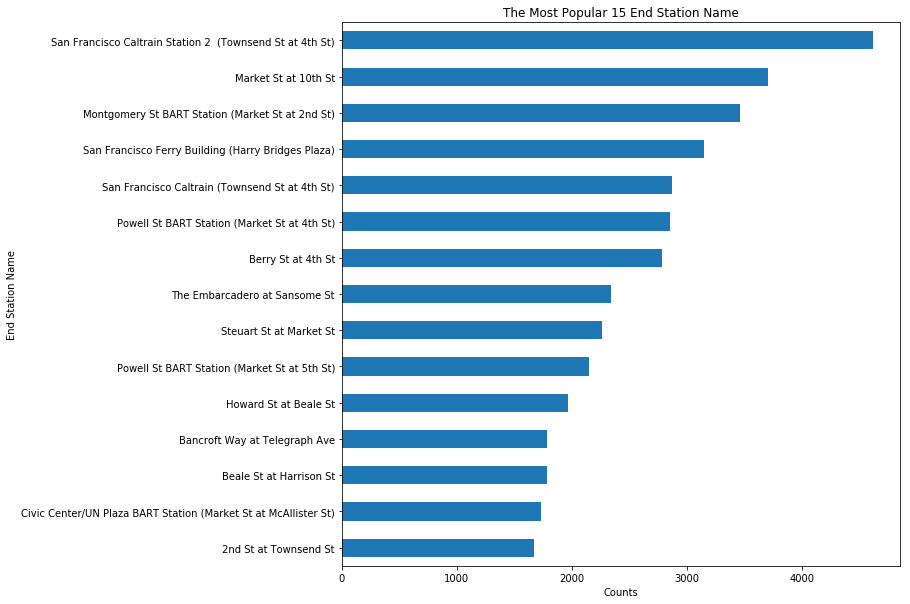

## Distribution of Biker

> 90.53% that undergo the trips were Subscriber while only 9.47% were Customer

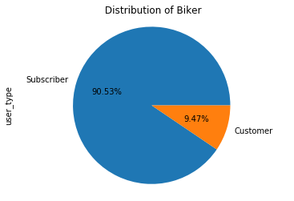

## Distribution of Start Day of the Biker

> The most active day to the start trip is Thurday

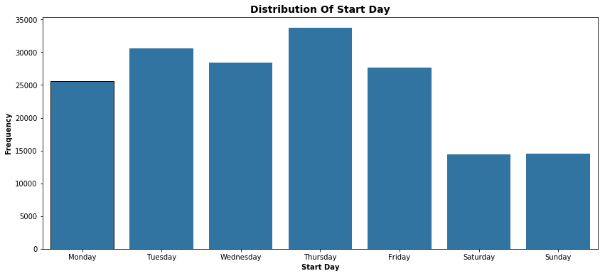

## Distribution of Start Hour Rate for the Trip

> The distribution of the start time chart show 2 peak of 8 hour and 17 hour

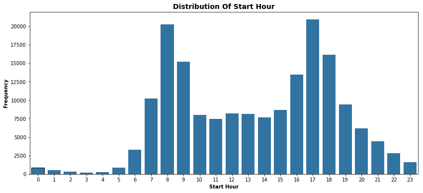

## Relationship Duration, Gender and User Type

> > Male User Subscriber have shorter Trip

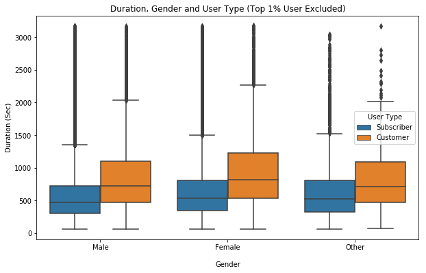

## Member Birth Year , Gender and User Type

> Both Male Customers and Subscribers Users has similar Age range that took the Trip compare to Female Users and Others

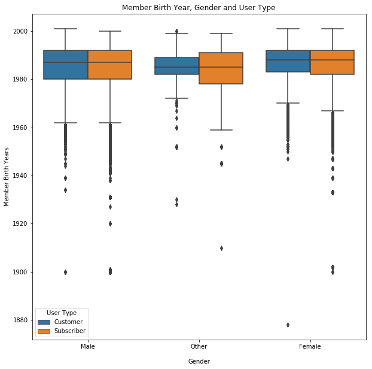

## Relationships of Duration, Gender and Day in 2D visualization

> 2D visualization showing distribution of Gender across the days of the week over the duration of trip in sec

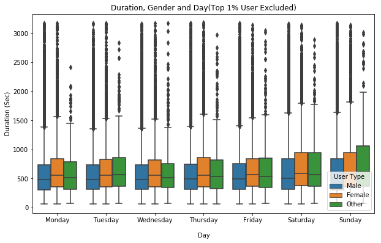